# Exploration of our data

### Trivariate graphics: Group the data.

I can easily add more groupings. Here I am coloring the points based on the value of a third variable: The variable can be continuous or categorical.

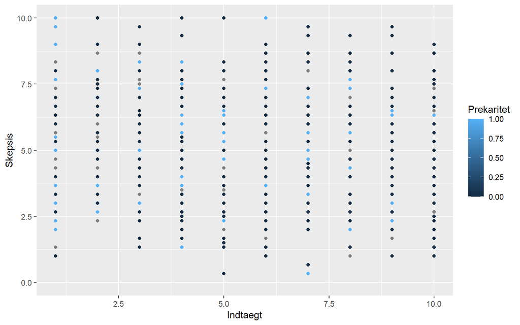

```r
ggplot(df) +
  geom_point(aes(y = Skepsis,
                 x = Indtaegt,
                 #Gruping
                 color = Prekaritet))
```

**Categorical grouping** If I want a categorical grouping, I need to feed the function a categorical variable (“character” or “factor”). It’s best to do this in the plot data, not in the ggplot() function. Right here, I deviate from this rule with (`as.factor()`)

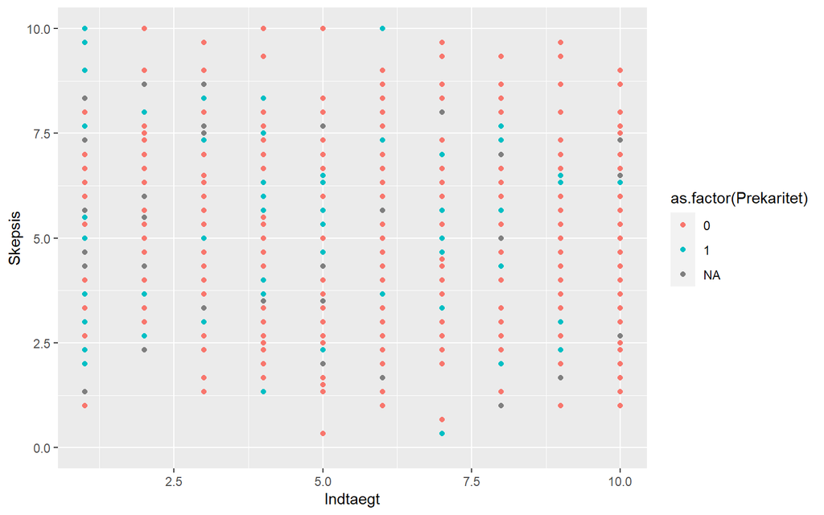

```r
ggplot(df) +
  geom_point(aes(y = Skepsis,
                 x = Indtaegt,
                 #Gruppering
                 color = as.factor(Prekaritet)))
```

One solution does not prevent another. Of course, I can combine all these solutions until I get a plot that tells the story I want to convey.

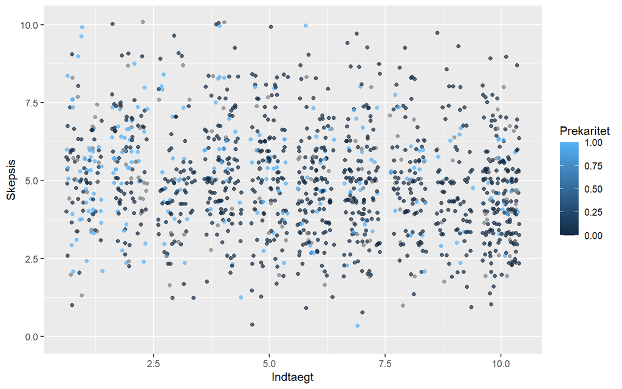

```r
ggplot(df) +
  geom_jitter(aes(y = Skepsis,
                 x = Indtaegt,
                 #Continuous moderating third variable
                 color = Prekaritet),
              #Shake data data horizontaly and vertically
              height = 0.1, width = 0.4,
              #Transparency
              alpha = 0.7)
```

### Bivariate regression lines

I can also show the relationship between two variables using regression lines. ggplot does not report regression coefficients but instead illustrates the regression line and the uncertainty around it. This is particularly relevant if at least one of the variables (the x-variable) is continuous.

Now we can choose between local regression and ordinary linear regression. Which one we choose depends on what we want to achieve.

#### Local regression

Local regression is – in my eyes – the queen of all ggplot functions. I use it all the time when exploring my data. It draws a “smooth” line (locally, the sliding average over the different x-values). Perfectly suited for time trends or exploring non-linear relationships, for example.

The function that gives us bivariate regression lines is `geom_smooth()`. The default setting is local regression.

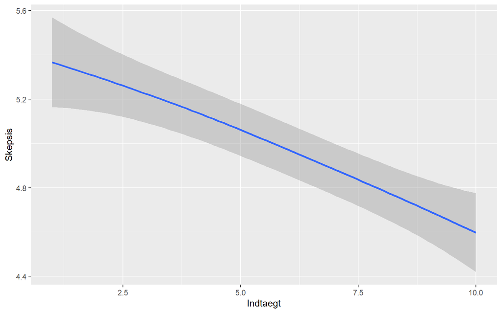

Local regression: A simple way to present empirical relationships between two variables.

```r
ggplot(df) +
  geom_smooth(aes(y = Skepsis,
                  x = Indtaegt))
```

R adjusts the “window” automatically for us, but we can choose the size ourselves. Then we use the additional argument span = . How much of the variable span should be used for the local average? Low values give a more jagged line, high values give more generalization.

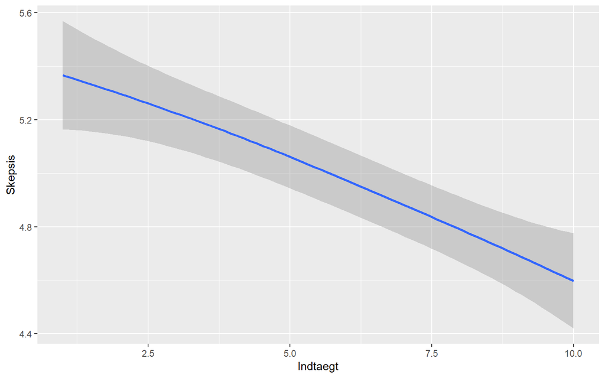

Local regression: A simple way to present a bivariate relationship.

```r
ggplot(df) +
  geom_smooth(aes(y = Skepsis,
                  x = Indtaegt),
              span = 20)
```

**Grouped:** Is the relationship the same within different categories?

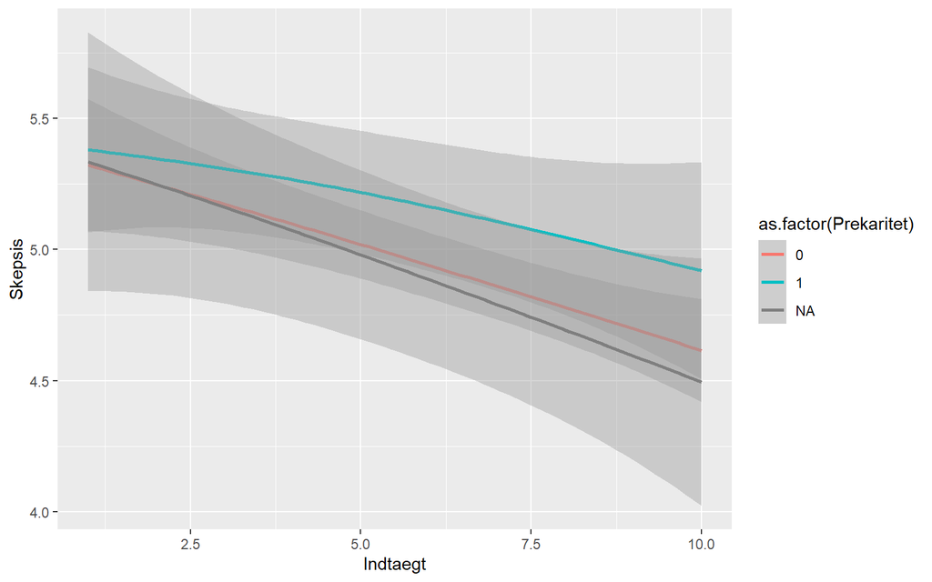

Local regression: The queen of trivariate plots?

```r
ggplot(df) +
  geom_smooth(aes(y = Skepsis,
                  x = Indtaegt,
                  color = as.factor(Prekaritet)))
```

Would you like to replace the “spaghetti” with straight lines? Ask for a (bivariate) linear model.

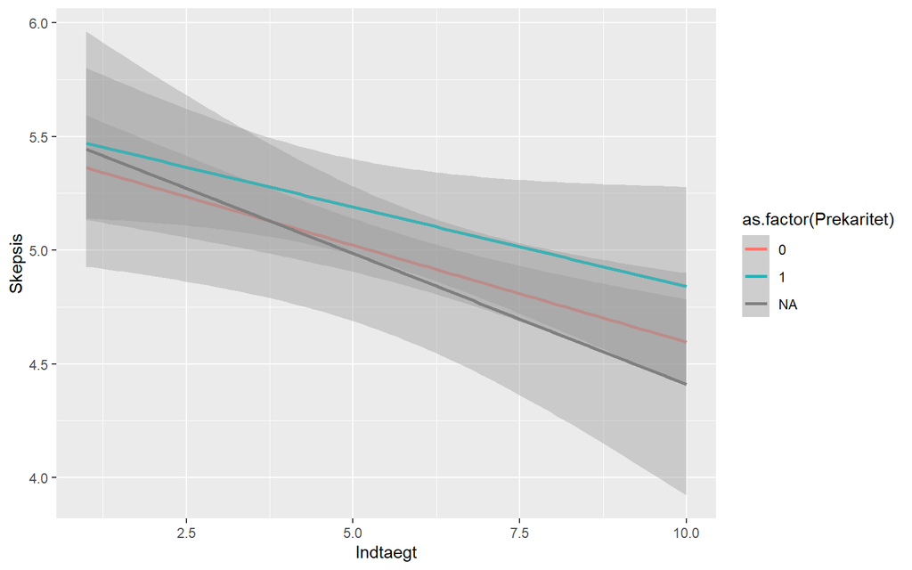

```r
ggplot(df) +
  geom_smooth(aes(y = Skepsis,
                  x = Indtaegt,
                  color = as.factor(Prekaritet)),
              method = "lm")
```

## One continous and one cagetorical variable (+ more tidyverse)

When we have a continous and a categorical variable we’d like to explore, we will usually calculate the group mean; i.e. we calculate the average of the continuous variable for each of the categories in the other.

This is a good excuse to have a second look at `tidyverse` . `dplyr` has a very handy function that allows us to do operations on subset of the data depending on a moderating variable.

Let’s calculate the average scepticism among voters of different parties and create a summary statistic. To do so, we use `summarize()`

```r
df %>%
  group_by(Parti) %>%
  summarize("Scepticism" = mean(Skepsis, na.rm = T))
```

| Parti | Scepticism |
| --- | --- |
| Andet | 5.343137 |
| Dansk Folkeparti | 6.290210 |
| Det Konservative Folkeparti | 4.846154 |
| Det Radikale Venstre | 4.067164 |
| Enhedslisten | 4.646930 |
| Kristendemokraterne | 4.333333 |
| Liberal Alliance | 4.934028 |
| Socialdemokraterne | 4.756266 |
| Socialistisk Folkeparti | 4.507716 |
| Venstre | 5.055376 |

[output cut: 1 more lines]

If we like this table, we can store it in an object. Before I do so, however, I’m removing the NAs.

```r
tab <-
  df %>%
  filter(!is.na(Parti)) %>%
  group_by(Parti) %>%
  summarize("Scepticism" = mean(Skepsis, na.rm = T))
```

The observations are ordered alphabetically. It is not intuitive. Let’s rearrange.

```r
tab <-
  tab %>%
  arrange(Scepticism)

tab
```

| Parti | Scepticism |
| --- | --- |
| Det Radikale Venstre | 4.067164 |
| Kristendemokraterne | 4.333333 |
| Socialistisk Folkeparti | 4.507716 |
| Enhedslisten | 4.646930 |
| Socialdemokraterne | 4.756266 |
| Det Konservative Folkeparti | 4.846154 |
| Liberal Alliance | 4.934028 |
| Venstre | 5.055376 |
| Andet | 5.343137 |
| Dansk Folkeparti | 6.290210 |

No surprises here; Dansk Folkeparti has voters that are more sceptical than other parties. This being said, in general, there is not a massive spread here.

Let’s instead plot this.

#### base

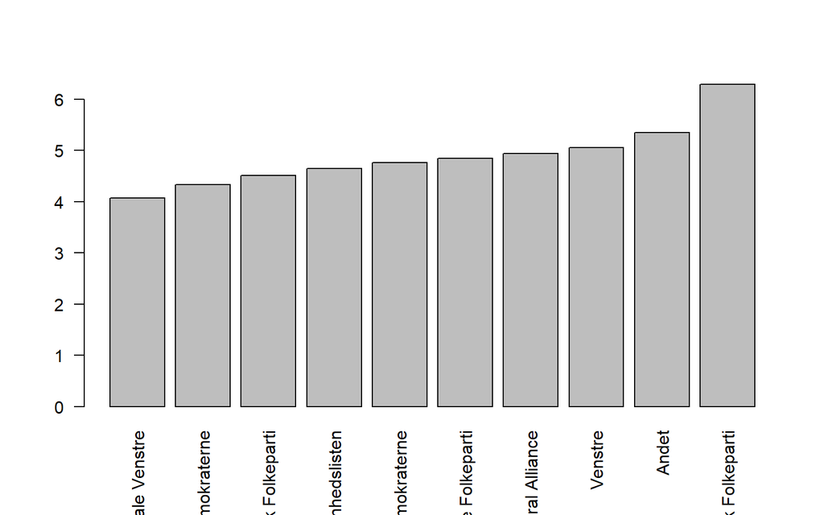

```r
barplot(tab$Scepticism,
        names.arg = tab$Parti,
        las = 2)
```

#### ggplot2

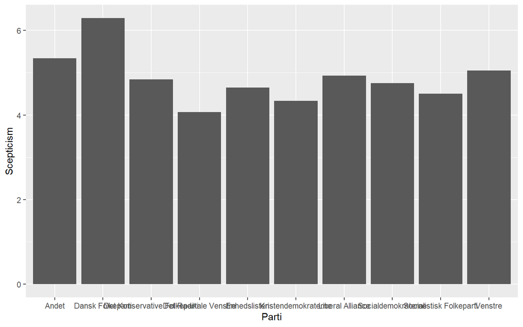

```r
ggplot(tab) +
  geom_histogram(aes(y = Scepticism,
                     x = Parti),
                 stat = "identity")
```

## Two categorical variables

When we have two categorical variables, we do a cross-table.

```r
table(df$Parti, df$Kvinde)
```

```
##
##                                 0   1
##   Andet                        11   6
##   Dansk Folkeparti             85  58
##   Det Konservative Folkeparti  33  32
##   Det Radikale Venstre         69  65
##   Enhedslisten                 32  45
##   Kristendemokraterne           4   4
##   Liberal Alliance             38  10
##   Socialdemokraterne          116 152
##   Socialistisk Folkeparti      43  65
##   Venstre                     175 136
```

Absolute frequencies are hard to fathom. I like them relative. Also, this time around, we want to know the proportion of voters that are men/women per party. It means that I calculate the distribution by rows (margin = 1).

```r
table(df$Parti, df$Kvinde) %>%
  prop.table(., margin = 1)
```

```
##
##                                       0         1
##   Andet                       0.6470588 0.3529412
##   Dansk Folkeparti            0.5944056 0.4055944
##   Det Konservative Folkeparti 0.5076923 0.4923077
##   Det Radikale Venstre        0.5149254 0.4850746
##   Enhedslisten                0.4155844 0.5844156
##   Kristendemokraterne         0.5000000 0.5000000
##   Liberal Alliance            0.7916667 0.2083333
##   Socialdemokraterne          0.4328358 0.5671642
##   Socialistisk Folkeparti     0.3981481 0.6018519
##   Venstre                     0.5627010 0.4372990
```

We don’t usually test the statistical significance, when we explore the data. However, we can. The chisquare test allows us to check if the data table is generated by random. The p-value reports the probability that the relationships we see are generated by accident. Here, that’s very unlikely.

```r
table(df$Parti, df$Kvinde) %>%
  chisq.test()
```

```
##
##  Pearson's Chi-squared test
##
## data:  .
## X-squared = 38.546, df = 9, p-value = 1.391e-05
```

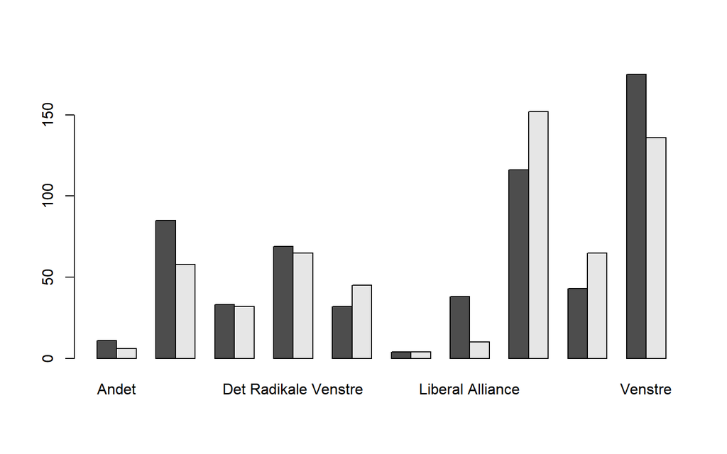

```r
table <- table(df$Kvinde, df$Parti)

barplot(table,
        beside = T)
```

#### ggplot2

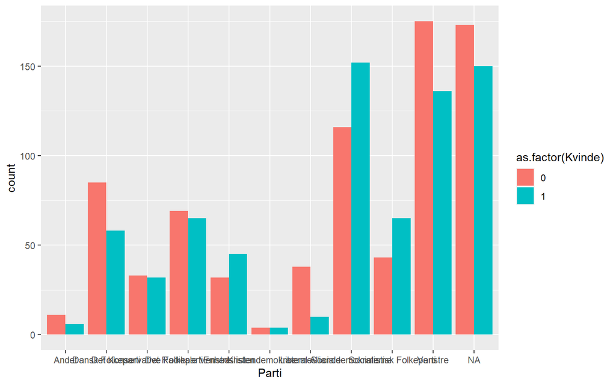

```r
ggplot(df) +
  geom_bar(aes(x = Parti,
               fill = as.factor(Kvinde)),
           position = "dodge")
```

# Workflow and tweaks in ggplot2

Let’s follow an alternative workflow and create our own small dataset for plotting. Here, I am interested in immigration skepticism among respondents with different work situations.

```r
dfp <- df %>%
  #Filter out NA
  filter(!is.na(Prekaritet)) %>%
  #Group
  group_by(Prekaritet) %>%
  #Group average
  summarize(Innvandringsskepsis = mean(Skepsis, na.rm = T))


#Make a new variable with the survey question

dfp$`How is your work situation?` <- dfp$Prekaritet %>%
  as.factor

#Omdefiner kategoriene til intuitive svar
levels(dfp$`How is your work situation?`) <- c("Insecure",
                                               "Secure")
```

Now you can ask R to plot

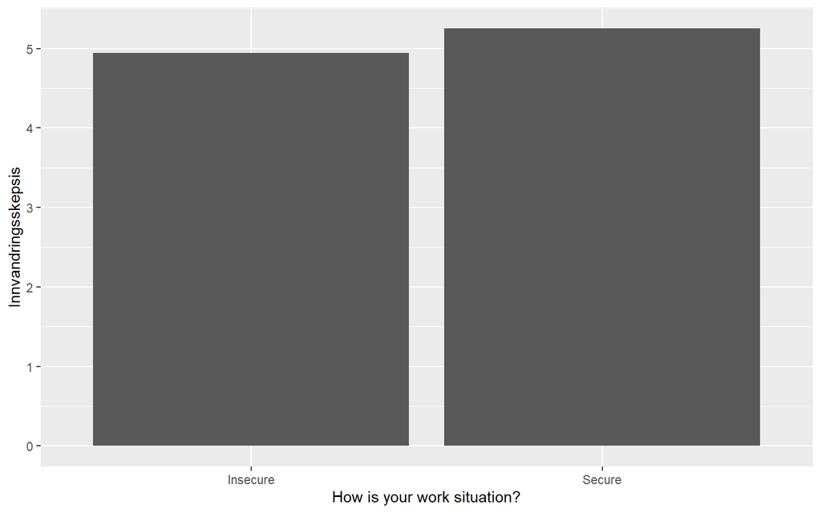

```r
ggplot(dfp) +
  #Classical definition of a coordinate system
  geom_bar(aes(y = Innvandringsskepsis,
               x = `How is your work situation?`),
           #Use the number you give as hight to the bars instead of calculating yourself
           stat = "identity")
```

```r
dfp <- df %>%
  #Filter out NA
  filter(!is.na(Prekaritet) & !is.na(Prekaritet)) %>%
  #Group
  group_by(Prekaritet, Kvinde) %>%
  #Group average
  summarize(Innvandringsskepsis = mean(Skepsis, na.rm = T))
#Make a new variable with the survey question
dfp$`How is your work situation?` <- dfp$Prekaritet %>%
  as.factor
#Omdefiner kategoriene til intuitive svar
levels(dfp$`How is your work situation?`) <- c("Precarious",
                                                        "Safe")
dfp$Gender = ifelse(dfp$Kvinde == 1,
                           "Woman", "Man")
dfp
```

| Prekaritet | Kvinde | Innvandringsskepsis | How is your work situation? | Gender |
| --- | --- | --- | --- | --- |
| 0 | 0 | 4.993151 | Precarious | Man |
| 0 | 1 | 4.891981 | Precarious | Woman |
| 1 | 0 | 5.245434 | Safe | Man |
| 1 | 1 | 5.257042 | Safe | Woman |

```r
p <-
  ggplot(dfp) +
  #Klassisk definisjon av både x og y koordinater
  geom_bar(aes(y = Innvandringsskepsis,
               x = `How is your work situation?`,
               #Fill in with colors following the grouping
               fill = Gender),
           #place bars side-by-side
           position = "dodge",
           #Bruker tallene du oppgir som søylehøyde uten å telle selv.
           stat = "identity")
```

Note how I have saved my plot in an object: `p <- ggplot()`. To see the plot, I request it.

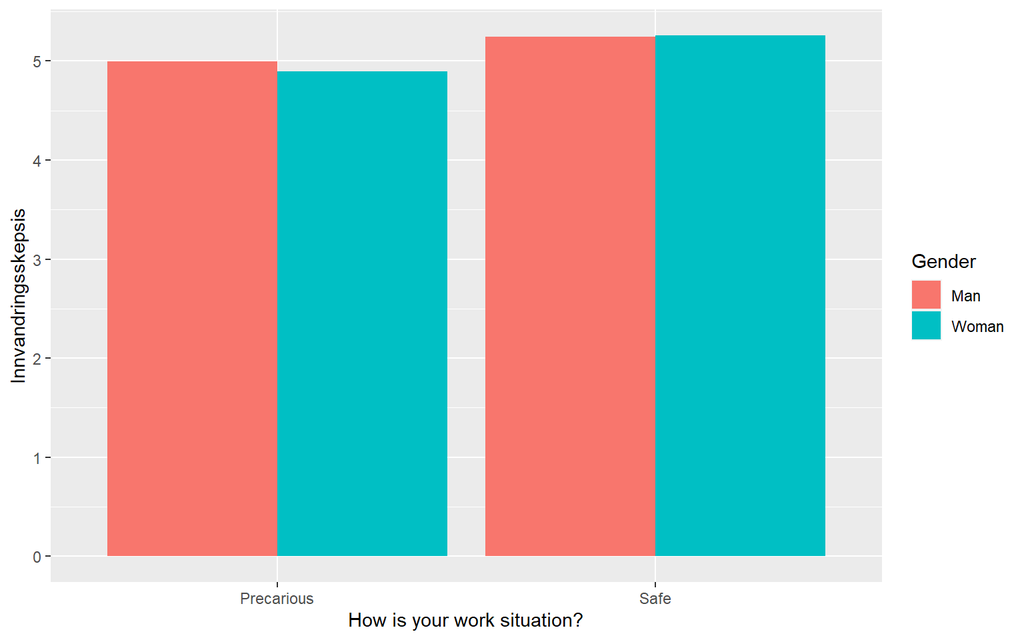

A bar chart created from a separate dataset where I have aggregated and prepared the information.

```r
p
```

It is useful to save the object this way because I will modify my R object further. I can do that using pipes.

### Esthetical tweaks

Once you have added the graphical elements with your data, you can spend an endless amount of time fine-tuning the rest of the plot.

### Tell R what language you speak (and where you are)

R was not created by Norwegians, so Danish characters can sometimes cause problems. We have to actively consider encoding choices in two settings: when we import data and when we save data, including in graphics.

```r
Sys.setlocale(category = "LC_ALL",
              locale = "dk_DK.UTF-8")
```

## Titles and axis names

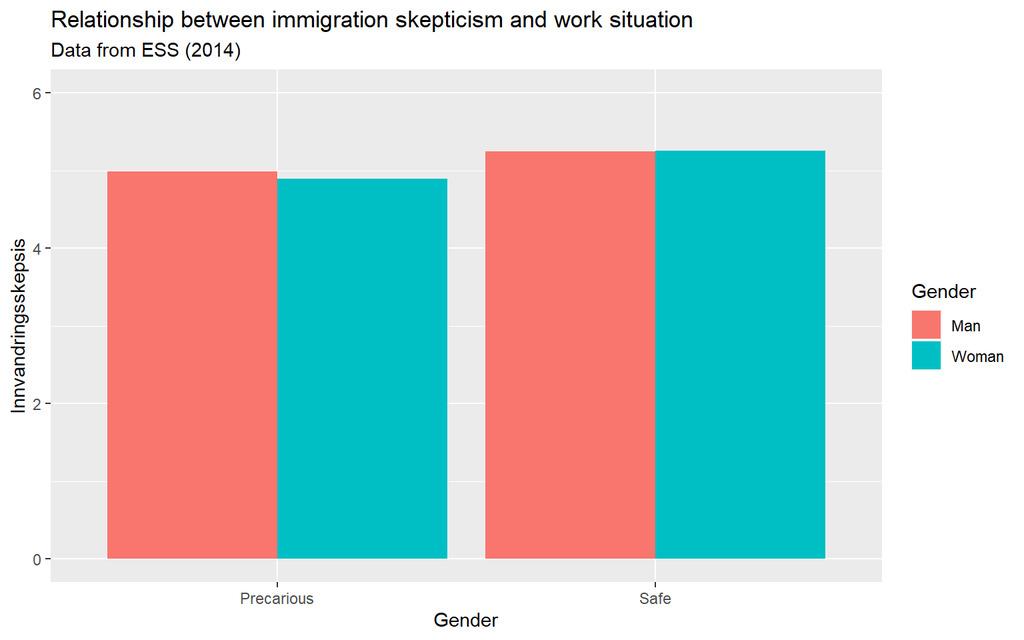

```r
p <-
  p +
  #Add a title and a subtitle
  ggtitle(label = "Relationship between immigration skepticism and work situation",
          subtitle = "Data from ESS (2014)") +
  #Name of x-axis
  xlab("Gender") +
  #What are the limits on my axis?
  ylim(c(0,6))

p
```

Define colors

You can choose your own colors, and there are many ways to do so. If you have linked your data with color choices, it may be useful to define a “palette.”

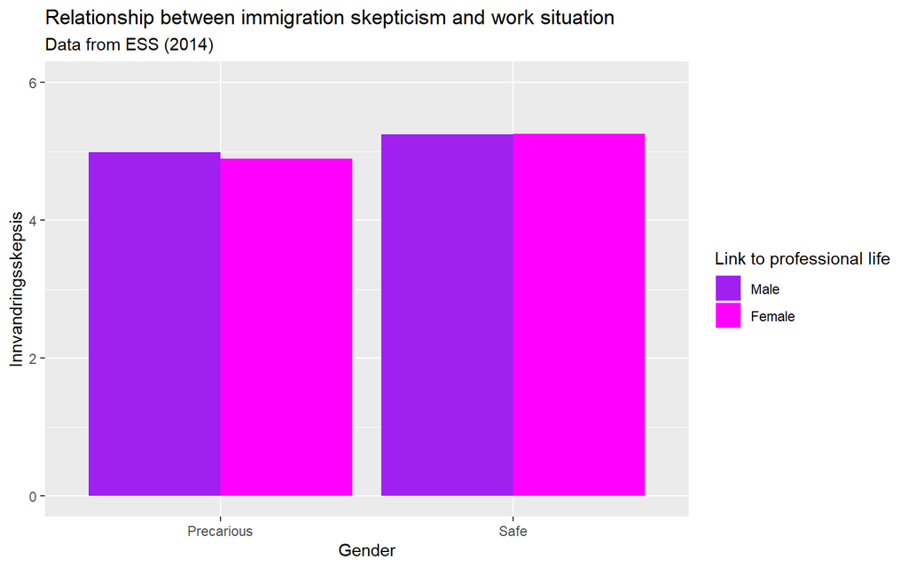

```r
p <-
  p +
  #Define colors
  scale_color_manual(
    #What colors?
    values = c("purple", "magenta"),
    #Color the entire bar
    aesthetics = "fill",
    #What's the title of the legend?
    name = "Link to professional life",
    #What are the category names?
    labels = c("Male",
               "Female")
    )
p
```

### Background

You can define different templates for the aesthetic aspects of the plot with `theme_...()`.

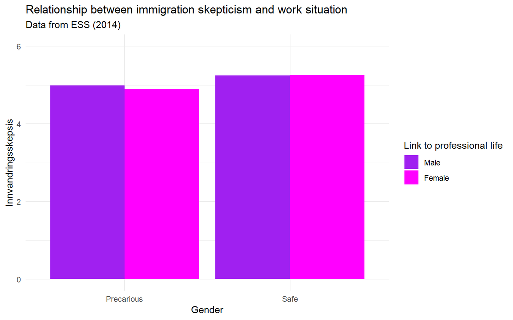

Here, I am using ready-made functions to modify the visual expression of the plot.

```r
p <-
  p +
  # Define a theme
  theme_minimal()
p
```

You can alter the themes at will. You do that after you have defined the theme, using the generik `theme()` function.

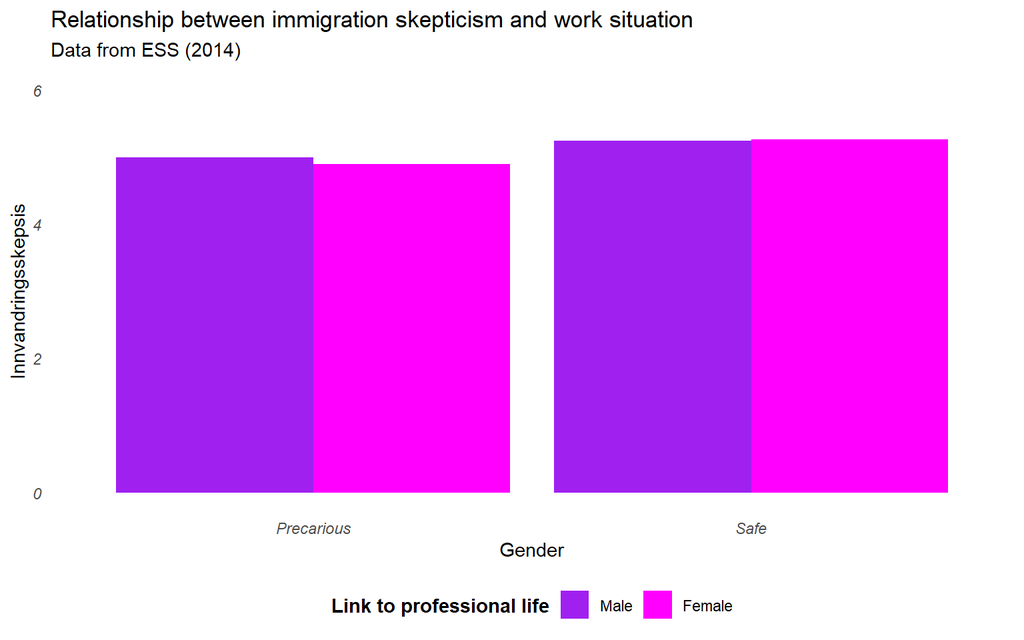

Here, I’ve changed the background and other thematical elements in my graphic.

```r
p <-
  p +
  # Modify the minimal theme after defining it
  theme(
    # Move the legend down to below the plot
    legend.position = "bottom",
    # Bold font for the title in the legend
    legend.title = element_text(face = "bold"),
    # Italic for axis values
    axis.text = element_text(face = "italic"),
    # Remove the gridlines
    panel.grid = element_blank())
p
```

The `element_...()` functions are used inside the `theme()` function. They specify everything except the data content/information for an element. Should it be a blank element element_blank()? Specific font? `element_text()`… etc.